# Risk Factor Analysis

## Outcome Variable

**Outcome Variable:** y_rate_haz

## Predictor Variables

**Intervention Variable:** nchldlt5

**Adjustment Set:**

- arm
- W_mage
- meducyrs
- feducyrs
- hhwealth_quart
- hfoodsec
- W_mhtcm
- W_mwtkg
- W_mbmi
- W_nrooms
- W_parity
- impfloor
- impsan
- safeh20
- delta_W_mage
- delta_meducyrs
- delta_feducyrs
- delta_hhwealth_quart
- delta_hfoodsec
- delta_W_mhtcm
- delta_W_mwtkg
- delta_W_mbmi
- delta_W_nrooms
- delta_W_parity
- delta_impfloor
- delta_impsan
- delta_safeh20

## Stratifying Variables

The analysis was stratified on these variable(s):

- agecat
- studyid
- country

## Data Summary

| agecat | studyid | country | nchldlt5 | n_cell | n | outcome_variable |
| --- | --- | --- | --- | --- | --- | --- |
| 0-3 months | ki1000108-IRC | INDIA | 1 | 82 | 377 | y_rate_haz |
| 0-3 months | ki1000108-IRC | INDIA | 2+ | 295 | 377 | y_rate_haz |
| 0-3 months | ki1017093b-PROVIDE | BANGLADESH | 1 | 471 | 640 | y_rate_haz |
| 0-3 months | ki1017093b-PROVIDE | BANGLADESH | 2+ | 169 | 640 | y_rate_haz |
| 0-3 months | ki1017093c-NIH-Crypto | BANGLADESH | 1 | 512 | 721 | y_rate_haz |
| 0-3 months | ki1017093c-NIH-Crypto | BANGLADESH | 2+ | 209 | 721 | y_rate_haz |
| 0-3 months | kiGH5241-JiVitA-3 | BANGLADESH | 1 | 12371 | 19861 | y_rate_haz |
| 0-3 months | kiGH5241-JiVitA-3 | BANGLADESH | 2+ | 7490 | 19861 | y_rate_haz |
| 3-6 months | ki1000108-IRC | INDIA | 1 | 87 | 397 | y_rate_haz |
| 3-6 months | ki1000108-IRC | INDIA | 2+ | 310 | 397 | y_rate_haz |
| 3-6 months | ki1017093b-PROVIDE | BANGLADESH | 1 | 434 | 598 | y_rate_haz |
| 3-6 months | ki1017093b-PROVIDE | BANGLADESH | 2+ | 164 | 598 | y_rate_haz |
| 3-6 months | ki1017093c-NIH-Crypto | BANGLADESH | 1 | 492 | 695 | y_rate_haz |
| 3-6 months | ki1017093c-NIH-Crypto | BANGLADESH | 2+ | 203 | 695 | y_rate_haz |
| 3-6 months | ki1066203-TanzaniaChild2 | TANZANIA, UNITED REPUBLIC OF | 1 | 1146 | 1656 | y_rate_haz |
| 3-6 months | ki1066203-TanzaniaChild2 | TANZANIA, UNITED REPUBLIC OF | 2+ | 510 | 1656 | y_rate_haz |
| 3-6 months | kiGH5241-JiVitA-3 | BANGLADESH | 1 | 8103 | 12572 | y_rate_haz |
| 3-6 months | kiGH5241-JiVitA-3 | BANGLADESH | 2+ | 4469 | 12572 | y_rate_haz |
| 6-9 months | ki1000108-IRC | INDIA | 1 | 89 | 407 | y_rate_haz |
| 6-9 months | ki1000108-IRC | INDIA | 2+ | 318 | 407 | y_rate_haz |
| 6-9 months | ki1017093b-PROVIDE | BANGLADESH | 1 | 410 | 565 | y_rate_haz |
| 6-9 months | ki1017093b-PROVIDE | BANGLADESH | 2+ | 155 | 565 | y_rate_haz |
| 6-9 months | ki1017093c-NIH-Crypto | BANGLADESH | 1 | 488 | 688 | y_rate_haz |
| 6-9 months | ki1017093c-NIH-Crypto | BANGLADESH | 2+ | 200 | 688 | y_rate_haz |
| 6-9 months | ki1066203-TanzaniaChild2 | TANZANIA, UNITED REPUBLIC OF | 1 | 1036 | 1480 | y_rate_haz |
| 6-9 months | ki1066203-TanzaniaChild2 | TANZANIA, UNITED REPUBLIC OF | 2+ | 444 | 1480 | y_rate_haz |
| 6-9 months | ki1148112-LCNI-5 | MALAWI | 1 | 261 | 557 | y_rate_haz |
| 6-9 months | ki1148112-LCNI-5 | MALAWI | 2+ | 296 | 557 | y_rate_haz |
| 9-12 months | ki1000108-IRC | INDIA | 1 | 88 | 400 | y_rate_haz |
| 9-12 months | ki1000108-IRC | INDIA | 2+ | 312 | 400 | y_rate_haz |

[output cut: 52 more lines]

The following strata were considered:

- agecat: 0-3 months, studyid: ki1000108-IRC, country: INDIA
- agecat: 0-3 months, studyid: ki1017093b-PROVIDE, country: BANGLADESH
- agecat: 0-3 months, studyid: ki1017093c-NIH-Crypto, country: BANGLADESH
- agecat: 0-3 months, studyid: kiGH5241-JiVitA-3, country: BANGLADESH
- agecat: 12-15 months, studyid: ki1000108-IRC, country: INDIA
- agecat: 12-15 months, studyid: ki1017093b-PROVIDE, country: BANGLADESH
- agecat: 12-15 months, studyid: ki1017093c-NIH-Crypto, country: BANGLADESH
- agecat: 12-15 months, studyid: ki1066203-TanzaniaChild2, country: TANZANIA, UNITED REPUBLIC OF
- agecat: 12-15 months, studyid: ki1112895-iLiNS-Zinc, country: BURKINA FASO
- agecat: 12-15 months, studyid: ki1148112-LCNI-5, country: MALAWI
- agecat: 15-18 months, studyid: ki1000108-IRC, country: INDIA
- agecat: 15-18 months, studyid: ki1017093b-PROVIDE, country: BANGLADESH
- agecat: 15-18 months, studyid: ki1017093c-NIH-Crypto, country: BANGLADESH
- agecat: 15-18 months, studyid: ki1066203-TanzaniaChild2, country: TANZANIA, UNITED REPUBLIC OF
- agecat: 15-18 months, studyid: ki1112895-iLiNS-Zinc, country: BURKINA FASO
- agecat: 15-18 months, studyid: ki1148112-LCNI-5, country: MALAWI
- agecat: 18-21 months, studyid: ki1000108-IRC, country: INDIA
- agecat: 18-21 months, studyid: ki1017093b-PROVIDE, country: BANGLADESH
- agecat: 18-21 months, studyid: ki1017093c-NIH-Crypto, country: BANGLADESH
- agecat: 18-21 months, studyid: ki1066203-TanzaniaChild2, country: TANZANIA, UNITED REPUBLIC OF
- agecat: 18-21 months, studyid: ki1148112-LCNI-5, country: MALAWI
- agecat: 21-24 months, studyid: ki1000108-IRC, country: INDIA
- agecat: 21-24 months, studyid: ki1017093b-PROVIDE, country: BANGLADESH
- agecat: 21-24 months, studyid: ki1017093c-NIH-Crypto, country: BANGLADESH
- agecat: 21-24 months, studyid: ki1148112-LCNI-5, country: MALAWI
- agecat: 3-6 months, studyid: ki1000108-IRC, country: INDIA
- agecat: 3-6 months, studyid: ki1017093b-PROVIDE, country: BANGLADESH
- agecat: 3-6 months, studyid: ki1017093c-NIH-Crypto, country: BANGLADESH
- agecat: 3-6 months, studyid: ki1066203-TanzaniaChild2, country: TANZANIA, UNITED REPUBLIC OF
- agecat: 3-6 months, studyid: kiGH5241-JiVitA-3, country: BANGLADESH
- agecat: 6-9 months, studyid: ki1000108-IRC, country: INDIA
- agecat: 6-9 months, studyid: ki1017093b-PROVIDE, country: BANGLADESH
- agecat: 6-9 months, studyid: ki1017093c-NIH-Crypto, country: BANGLADESH
- agecat: 6-9 months, studyid: ki1066203-TanzaniaChild2, country: TANZANIA, UNITED REPUBLIC OF
- agecat: 6-9 months, studyid: ki1148112-LCNI-5, country: MALAWI
- agecat: 9-12 months, studyid: ki1000108-IRC, country: INDIA
- agecat: 9-12 months, studyid: ki1017093b-PROVIDE, country: BANGLADESH
- agecat: 9-12 months, studyid: ki1017093c-NIH-Crypto, country: BANGLADESH
- agecat: 9-12 months, studyid: ki1066203-TanzaniaChild2, country: TANZANIA, UNITED REPUBLIC OF
- agecat: 9-12 months, studyid: ki1112895-iLiNS-Zinc, country: BURKINA FASO
- agecat: 9-12 months, studyid: ki1148112-LCNI-5, country: MALAWI

### Dropped Strata

Some strata were dropped due to rare outcomes:

- agecat: 18-21 months, studyid: ki1066203-TanzaniaChild2, country: TANZANIA, UNITED REPUBLIC OF

## Methods Detail

We’re interested in the causal parameters $E[Y_a]$ for all values of $a \in \mathcal{A}$. These parameters represent the mean outcome if, possibly contrary to fact, we intervened to set all units to have $A=a$. Under the randomization and positivity assumptions, these are identified by the statistical parameters $\psi_a=E_W[E_{Y|A,W}(Y|A=a,W)]$. In addition, we’re interested in the mean of $Y$, $E[Y]$ under no intervention (the observed mean). We will estimate these parameters by using SuperLearner to fit the relevant likelihood factors – $E_{Y|A,W}(Y|A=a,W)$ and $p(A=a|W)$, and then updating our likelihood fit using a joint TMLE.

For unadjusted analyses ($W=\{\}$), initial likelihoods were estimated using Lrnr_glm to estimate the simple $E(Y|A)$ and Lrnr_mean to estimate $p(A)$. For adjusted analyses, a small library containing Lrnr_glmnet, Lrnr_xgboost, and Lrnr_mean was used.

Having estimated these parameters, we will then use the delta method to estimate relative risks and attributable risks relative to a prespecified baseline level of $A$.

# Results Detail

## Results Plots

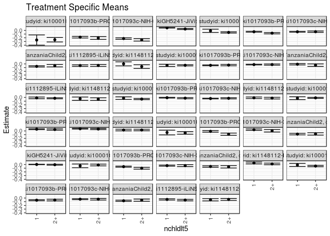

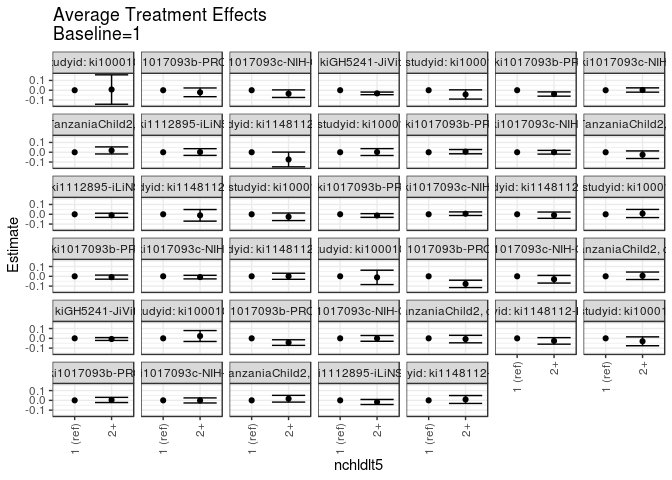

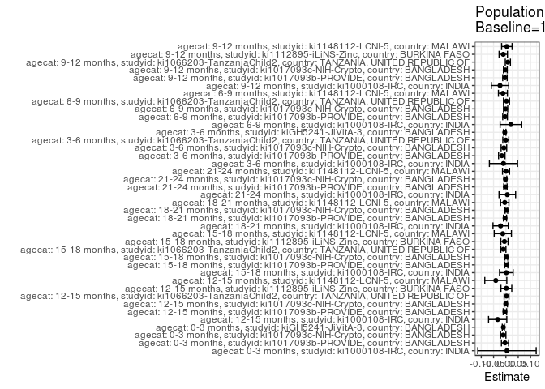

## Results Table

### Parameter: TSM

| agecat | studyid | country | intervention_level | baseline_level | estimate | ci_lower | ci_upper |
| --- | --- | --- | --- | --- | --- | --- | --- |
| 0-3 months | ki1000108-IRC | INDIA | 1 | NA | -0.2603247 | -0.3978074 | -0.1228421 |
| 0-3 months | ki1000108-IRC | INDIA | 2+ | NA | -0.2531914 | -0.3132056 | -0.1931773 |
| 0-3 months | ki1017093b-PROVIDE | BANGLADESH | 1 | NA | -0.1844709 | -0.2074149 | -0.1615269 |
| 0-3 months | ki1017093b-PROVIDE | BANGLADESH | 2+ | NA | -0.2060102 | -0.2442793 | -0.1677411 |
| 0-3 months | ki1017093c-NIH-Crypto | BANGLADESH | 1 | NA | -0.2205412 | -0.2412969 | -0.1997856 |
| 0-3 months | ki1017093c-NIH-Crypto | BANGLADESH | 2+ | NA | -0.2559976 | -0.2885640 | -0.2234312 |
| 0-3 months | kiGH5241-JiVitA-3 | BANGLADESH | 1 | NA | 0.0691705 | 0.0627194 | 0.0756217 |
| 0-3 months | kiGH5241-JiVitA-3 | BANGLADESH | 2+ | NA | 0.0369553 | 0.0247345 | 0.0491760 |
| 3-6 months | ki1000108-IRC | INDIA | 1 | NA | -0.0421265 | -0.1067681 | 0.0225150 |
| 3-6 months | ki1000108-IRC | INDIA | 2+ | NA | -0.0532462 | -0.0872242 | -0.0192683 |
| 3-6 months | ki1017093b-PROVIDE | BANGLADESH | 1 | NA | -0.0103407 | -0.0315167 | 0.0108353 |
| 3-6 months | ki1017093b-PROVIDE | BANGLADESH | 2+ | NA | -0.0878227 | -0.1190011 | -0.0566444 |
| 3-6 months | ki1017093c-NIH-Crypto | BANGLADESH | 1 | NA | 0.0348096 | 0.0149473 | 0.0546718 |
| 3-6 months | ki1017093c-NIH-Crypto | BANGLADESH | 2+ | NA | 0.0048651 | -0.0288917 | 0.0386218 |
| 3-6 months | ki1066203-TanzaniaChild2 | TANZANIA, UNITED REPUBLIC OF | 1 | NA | -0.0853316 | -0.1065611 | -0.0641021 |
| 3-6 months | ki1066203-TanzaniaChild2 | TANZANIA, UNITED REPUBLIC OF | 2+ | NA | -0.0798754 | -0.1115687 | -0.0481821 |
| 3-6 months | kiGH5241-JiVitA-3 | BANGLADESH | 1 | NA | 0.0011068 | -0.0057597 | 0.0079733 |
| 3-6 months | kiGH5241-JiVitA-3 | BANGLADESH | 2+ | NA | -0.0058586 | -0.0188215 | 0.0071043 |
| 6-9 months | ki1000108-IRC | INDIA | 1 | NA | -0.0367169 | -0.0869415 | 0.0135077 |
| 6-9 months | ki1000108-IRC | INDIA | 2+ | NA | -0.0130953 | -0.0375372 | 0.0113466 |
| 6-9 months | ki1017093b-PROVIDE | BANGLADESH | 1 | NA | -0.0580866 | -0.0729572 | -0.0432161 |
| 6-9 months | ki1017093b-PROVIDE | BANGLADESH | 2+ | NA | -0.1014714 | -0.1257946 | -0.0771482 |
| 6-9 months | ki1017093c-NIH-Crypto | BANGLADESH | 1 | NA | -0.0302085 | -0.0448832 | -0.0155338 |
| 6-9 months | ki1017093c-NIH-Crypto | BANGLADESH | 2+ | NA | -0.0308126 | -0.0563797 | -0.0052455 |
| 6-9 months | ki1066203-TanzaniaChild2 | TANZANIA, UNITED REPUBLIC OF | 1 | NA | -0.0541079 | -0.0740966 | -0.0341192 |
| 6-9 months | ki1066203-TanzaniaChild2 | TANZANIA, UNITED REPUBLIC OF | 2+ | NA | -0.0617635 | -0.0941368 | -0.0293903 |
| 6-9 months | ki1148112-LCNI-5 | MALAWI | 1 | NA | 0.0411829 | 0.0161478 | 0.0662181 |
| 6-9 months | ki1148112-LCNI-5 | MALAWI | 2+ | NA | 0.0148756 | -0.0069354 | 0.0366865 |
| 9-12 months | ki1000108-IRC | INDIA | 1 | NA | -0.0124052 | -0.0537900 | 0.0289796 |
| 9-12 months | ki1000108-IRC | INDIA | 2+ | NA | -0.0427583 | -0.0609718 | -0.0245449 |
| 9-12 months | ki1017093b-PROVIDE | BANGLADESH | 1 | NA | -0.0592532 | -0.0741560 | -0.0443503 |
| 9-12 months | ki1017093b-PROVIDE | BANGLADESH | 2+ | NA | -0.0550895 | -0.0769350 | -0.0332440 |
| 9-12 months | ki1017093c-NIH-Crypto | BANGLADESH | 1 | NA | -0.0321135 | -0.0453550 | -0.0188720 |
| 9-12 months | ki1017093c-NIH-Crypto | BANGLADESH | 2+ | NA | -0.0330916 | -0.0549002 | -0.0112831 |
| 9-12 months | ki1066203-TanzaniaChild2 | TANZANIA, UNITED REPUBLIC OF | 1 | NA | -0.0739214 | -0.0905137 | -0.0573291 |
| 9-12 months | ki1066203-TanzaniaChild2 | TANZANIA, UNITED REPUBLIC OF | 2+ | NA | -0.0574498 | -0.0876708 | -0.0272287 |
| 9-12 months | ki1112895-iLiNS-Zinc | BURKINA FASO | 1 | NA | -0.0390220 | -0.0562051 | -0.0218390 |
| 9-12 months | ki1112895-iLiNS-Zinc | BURKINA FASO | 2+ | NA | -0.0558471 | -0.0760535 | -0.0356407 |
| 9-12 months | ki1148112-LCNI-5 | MALAWI | 1 | NA | -0.0472400 | -0.0773268 | -0.0171531 |
| 9-12 months | ki1148112-LCNI-5 | MALAWI | 2+ | NA | -0.0383136 | -0.0642969 | -0.0123304 |
| 12-15 months | ki1000108-IRC | INDIA | 1 | NA | -0.0121693 | -0.0565717 | 0.0322330 |
| 12-15 months | ki1000108-IRC | INDIA | 2+ | NA | -0.0554869 | -0.0724910 | -0.0384829 |
| 12-15 months | ki1017093b-PROVIDE | BANGLADESH | 1 | NA | -0.0370401 | -0.0495596 | -0.0245206 |
| 12-15 months | ki1017093b-PROVIDE | BANGLADESH | 2+ | NA | -0.0759860 | -0.0938003 | -0.0581718 |
| 12-15 months | ki1017093c-NIH-Crypto | BANGLADESH | 1 | NA | -0.0379624 | -0.0493263 | -0.0265984 |
| 12-15 months | ki1017093c-NIH-Crypto | BANGLADESH | 2+ | NA | -0.0358260 | -0.0543720 | -0.0172801 |
| 12-15 months | ki1066203-TanzaniaChild2 | TANZANIA, UNITED REPUBLIC OF | 1 | NA | -0.0670625 | -0.0841320 | -0.0499930 |
| 12-15 months | ki1066203-TanzaniaChild2 | TANZANIA, UNITED REPUBLIC OF | 2+ | NA | -0.0486684 | -0.0803773 | -0.0169596 |
| 12-15 months | ki1112895-iLiNS-Zinc | BURKINA FASO | 1 | NA | -0.0448814 | -0.0658893 | -0.0238734 |
| 12-15 months | ki1112895-iLiNS-Zinc | BURKINA FASO | 2+ | NA | -0.0429448 | -0.0683738 | -0.0175157 |
| 12-15 months | ki1148112-LCNI-5 | MALAWI | 1 | NA | 0.0009610 | -0.0541980 | 0.0561199 |
| 12-15 months | ki1148112-LCNI-5 | MALAWI | 2+ | NA | -0.0728160 | -0.1233515 | -0.0222805 |
| 15-18 months | ki1000108-IRC | INDIA | 1 | NA | -0.0403460 | -0.0713971 | -0.0092950 |
| 15-18 months | ki1000108-IRC | INDIA | 2+ | NA | -0.0385175 | -0.0547685 | -0.0222665 |
| 15-18 months | ki1017093b-PROVIDE | BANGLADESH | 1 | NA | -0.0391262 | -0.0503921 | -0.0278603 |
| 15-18 months | ki1017093b-PROVIDE | BANGLADESH | 2+ | NA | -0.0331692 | -0.0514922 | -0.0148461 |
| 15-18 months | ki1017093c-NIH-Crypto | BANGLADESH | 1 | NA | -0.0183289 | -0.0283749 | -0.0082828 |
| 15-18 months | ki1017093c-NIH-Crypto | BANGLADESH | 2+ | NA | -0.0182340 | -0.0344377 | -0.0020303 |
| 15-18 months | ki1066203-TanzaniaChild2 | TANZANIA, UNITED REPUBLIC OF | 1 | NA | -0.0092647 | -0.0276226 | 0.0090933 |
| 15-18 months | ki1066203-TanzaniaChild2 | TANZANIA, UNITED REPUBLIC OF | 2+ | NA | -0.0345357 | -0.0685340 | -0.0005375 |
| 15-18 months | ki1112895-iLiNS-Zinc | BURKINA FASO | 1 | NA | -0.0120653 | -0.0341056 | 0.0099750 |
| 15-18 months | ki1112895-iLiNS-Zinc | BURKINA FASO | 2+ | NA | -0.0225523 | -0.0362174 | -0.0088871 |
| 15-18 months | ki1148112-LCNI-5 | MALAWI | 1 | NA | -0.0349162 | -0.0801104 | 0.0102781 |
| 15-18 months | ki1148112-LCNI-5 | MALAWI | 2+ | NA | -0.0457068 | -0.0814910 | -0.0099225 |
| 18-21 months | ki1000108-IRC | INDIA | 1 | NA | -0.0187037 | -0.0538383 | 0.0164310 |
| 18-21 months | ki1000108-IRC | INDIA | 2+ | NA | -0.0445620 | -0.0593317 | -0.0297924 |
| 18-21 months | ki1017093b-PROVIDE | BANGLADESH | 1 | NA | -0.0074241 | -0.0180054 | 0.0031571 |
| 18-21 months | ki1017093b-PROVIDE | BANGLADESH | 2+ | NA | -0.0199065 | -0.0354614 | -0.0043516 |
| 18-21 months | ki1017093c-NIH-Crypto | BANGLADESH | 1 | NA | -0.0299009 | -0.0394652 | -0.0203365 |
| 18-21 months | ki1017093c-NIH-Crypto | BANGLADESH | 2+ | NA | -0.0240641 | -0.0396567 | -0.0084715 |
| 18-21 months | ki1148112-LCNI-5 | MALAWI | 1 | NA | -0.0098474 | -0.0312629 | 0.0115682 |
| 18-21 months | ki1148112-LCNI-5 | MALAWI | 2+ | NA | -0.0190603 | -0.0422461 | 0.0041256 |
| 21-24 months | ki1000108-IRC | INDIA | 1 | NA | -0.0197269 | -0.0588331 | 0.0193792 |
| 21-24 months | ki1000108-IRC | INDIA | 2+ | NA | -0.0118518 | -0.0263154 | 0.0026118 |
| 21-24 months | ki1017093b-PROVIDE | BANGLADESH | 1 | NA | 0.0482154 | 0.0374929 | 0.0589378 |
| 21-24 months | ki1017093b-PROVIDE | BANGLADESH | 2+ | NA | 0.0395753 | 0.0217645 | 0.0573860 |
| 21-24 months | ki1017093c-NIH-Crypto | BANGLADESH | 1 | NA | 0.0606434 | 0.0503705 | 0.0709163 |
| 21-24 months | ki1017093c-NIH-Crypto | BANGLADESH | 2+ | NA | 0.0524612 | 0.0373482 | 0.0675742 |
| 21-24 months | ki1148112-LCNI-5 | MALAWI | 1 | NA | 0.0248349 | 0.0021548 | 0.0475150 |
| 21-24 months | ki1148112-LCNI-5 | MALAWI | 2+ | NA | 0.0253136 | 0.0048090 | 0.0458183 |

### Parameter: E(Y)

| agecat | studyid | country | intervention_level | baseline_level | estimate | ci_lower | ci_upper |
| --- | --- | --- | --- | --- | --- | --- | --- |
| 0-3 months | ki1000108-IRC | INDIA | NA | NA | -0.2558271 | -0.3111464 | -0.2005078 |
| 0-3 months | ki1017093b-PROVIDE | BANGLADESH | NA | NA | -0.1880402 | -0.2054115 | -0.1706689 |
| 0-3 months | ki1017093c-NIH-Crypto | BANGLADESH | NA | NA | -0.2312607 | -0.2486732 | -0.2138483 |
| 0-3 months | kiGH5241-JiVitA-3 | BANGLADESH | NA | NA | 0.0588634 | 0.0539415 | 0.0637854 |
| 3-6 months | ki1000108-IRC | INDIA | NA | NA | -0.0518918 | -0.0819849 | -0.0217987 |
| 3-6 months | ki1017093b-PROVIDE | BANGLADESH | NA | NA | -0.0269625 | -0.0428628 | -0.0110622 |
| 3-6 months | ki1017093c-NIH-Crypto | BANGLADESH | NA | NA | 0.0267740 | 0.0099602 | 0.0435879 |
| 3-6 months | ki1066203-TanzaniaChild2 | TANZANIA, UNITED REPUBLIC OF | NA | NA | -0.0856607 | -0.1022688 | -0.0690525 |
| 3-6 months | kiGH5241-JiVitA-3 | BANGLADESH | NA | NA | -0.0034167 | -0.0082813 | 0.0014478 |
| 6-9 months | ki1000108-IRC | INDIA | NA | NA | -0.0162677 | -0.0378604 | 0.0053250 |
| 6-9 months | ki1017093b-PROVIDE | BANGLADESH | NA | NA | -0.0614264 | -0.0722690 | -0.0505838 |
| 6-9 months | ki1017093c-NIH-Crypto | BANGLADESH | NA | NA | -0.0313638 | -0.0441155 | -0.0186120 |
| 6-9 months | ki1066203-TanzaniaChild2 | TANZANIA, UNITED REPUBLIC OF | NA | NA | -0.0516546 | -0.0677408 | -0.0355685 |
| 6-9 months | ki1148112-LCNI-5 | MALAWI | NA | NA | 0.0291520 | 0.0132692 | 0.0450348 |
| 9-12 months | ki1000108-IRC | INDIA | NA | NA | -0.0361313 | -0.0530672 | -0.0191954 |
| 9-12 months | ki1017093b-PROVIDE | BANGLADESH | NA | NA | -0.0630470 | -0.0740183 | -0.0520757 |
| 9-12 months | ki1017093c-NIH-Crypto | BANGLADESH | NA | NA | -0.0342995 | -0.0452397 | -0.0233593 |
| 9-12 months | ki1066203-TanzaniaChild2 | TANZANIA, UNITED REPUBLIC OF | NA | NA | -0.0659765 | -0.0802683 | -0.0516847 |
| 9-12 months | ki1112895-iLiNS-Zinc | BURKINA FASO | NA | NA | -0.0495887 | -0.0642303 | -0.0349470 |
| 9-12 months | ki1148112-LCNI-5 | MALAWI | NA | NA | -0.0433141 | -0.0626948 | -0.0239333 |
| 12-15 months | ki1000108-IRC | INDIA | NA | NA | -0.0454519 | -0.0622041 | -0.0286997 |
| 12-15 months | ki1017093b-PROVIDE | BANGLADESH | NA | NA | -0.0409107 | -0.0510053 | -0.0308161 |
| 12-15 months | ki1017093c-NIH-Crypto | BANGLADESH | NA | NA | -0.0383313 | -0.0478154 | -0.0288473 |
| 12-15 months | ki1066203-TanzaniaChild2 | TANZANIA, UNITED REPUBLIC OF | NA | NA | -0.0644098 | -0.0788912 | -0.0499283 |
| 12-15 months | ki1112895-iLiNS-Zinc | BURKINA FASO | NA | NA | -0.0429646 | -0.0592166 | -0.0267126 |
| 12-15 months | ki1148112-LCNI-5 | MALAWI | NA | NA | -0.0399695 | -0.0773378 | -0.0026011 |
| 15-18 months | ki1000108-IRC | INDIA | NA | NA | -0.0385167 | -0.0531981 | -0.0238352 |
| 15-18 months | ki1017093b-PROVIDE | BANGLADESH | NA | NA | -0.0376437 | -0.0463882 | -0.0288992 |
| 15-18 months | ki1017093c-NIH-Crypto | BANGLADESH | NA | NA | -0.0169074 | -0.0252557 | -0.0085590 |
| 15-18 months | ki1066203-TanzaniaChild2 | TANZANIA, UNITED REPUBLIC OF | NA | NA | -0.0193878 | -0.0347002 | -0.0040754 |
| 15-18 months | ki1112895-iLiNS-Zinc | BURKINA FASO | NA | NA | -0.0178586 | -0.0309796 | -0.0047376 |
| 15-18 months | ki1148112-LCNI-5 | MALAWI | NA | NA | -0.0474219 | -0.0733675 | -0.0214763 |
| 18-21 months | ki1000108-IRC | INDIA | NA | NA | -0.0400816 | -0.0533440 | -0.0268193 |
| 18-21 months | ki1017093b-PROVIDE | BANGLADESH | NA | NA | -0.0109399 | -0.0190984 | -0.0027814 |
| 18-21 months | ki1017093c-NIH-Crypto | BANGLADESH | NA | NA | -0.0279687 | -0.0360019 | -0.0199355 |
| 18-21 months | ki1148112-LCNI-5 | MALAWI | NA | NA | -0.0144661 | -0.0307469 | 0.0018148 |
| 21-24 months | ki1000108-IRC | INDIA | NA | NA | -0.0139081 | -0.0274784 | -0.0003379 |
| 21-24 months | ki1017093b-PROVIDE | BANGLADESH | NA | NA | 0.0462342 | 0.0375872 | 0.0548812 |
| 21-24 months | ki1017093c-NIH-Crypto | BANGLADESH | NA | NA | 0.0587621 | 0.0505315 | 0.0669927 |
| 21-24 months | ki1148112-LCNI-5 | MALAWI | NA | NA | 0.0254759 | 0.0100795 | 0.0408724 |

### Parameter: ATE

| agecat | studyid | country | intervention_level | baseline_level | estimate | ci_lower | ci_upper |
| --- | --- | --- | --- | --- | --- | --- | --- |
| 0-3 months | ki1000108-IRC | INDIA | 1 | 1 | 0.0000000 | 0.0000000 | 0.0000000 |
| 0-3 months | ki1000108-IRC | INDIA | 2+ | 1 | 0.0071333 | -0.1430138 | 0.1572804 |
| 0-3 months | ki1017093b-PROVIDE | BANGLADESH | 1 | 1 | 0.0000000 | 0.0000000 | 0.0000000 |
| 0-3 months | ki1017093b-PROVIDE | BANGLADESH | 2+ | 1 | -0.0215393 | -0.0662306 | 0.0231520 |
| 0-3 months | ki1017093c-NIH-Crypto | BANGLADESH | 1 | 1 | 0.0000000 | 0.0000000 | 0.0000000 |
| 0-3 months | ki1017093c-NIH-Crypto | BANGLADESH | 2+ | 1 | -0.0354564 | -0.0740270 | 0.0031143 |
| 0-3 months | kiGH5241-JiVitA-3 | BANGLADESH | 1 | 1 | 0.0000000 | 0.0000000 | 0.0000000 |
| 0-3 months | kiGH5241-JiVitA-3 | BANGLADESH | 2+ | 1 | -0.0322153 | -0.0456248 | -0.0188058 |
| 3-6 months | ki1000108-IRC | INDIA | 1 | 1 | 0.0000000 | 0.0000000 | 0.0000000 |
| 3-6 months | ki1000108-IRC | INDIA | 2+ | 1 | -0.0111197 | -0.0845642 | 0.0623247 |
| 3-6 months | ki1017093b-PROVIDE | BANGLADESH | 1 | 1 | 0.0000000 | 0.0000000 | 0.0000000 |
| 3-6 months | ki1017093b-PROVIDE | BANGLADESH | 2+ | 1 | -0.0774820 | -0.1151876 | -0.0397765 |
| 3-6 months | ki1017093c-NIH-Crypto | BANGLADESH | 1 | 1 | 0.0000000 | 0.0000000 | 0.0000000 |
| 3-6 months | ki1017093c-NIH-Crypto | BANGLADESH | 2+ | 1 | -0.0299445 | -0.0690315 | 0.0091425 |
| 3-6 months | ki1066203-TanzaniaChild2 | TANZANIA, UNITED REPUBLIC OF | 1 | 1 | 0.0000000 | 0.0000000 | 0.0000000 |
| 3-6 months | ki1066203-TanzaniaChild2 | TANZANIA, UNITED REPUBLIC OF | 2+ | 1 | 0.0054562 | -0.0327670 | 0.0436794 |
| 3-6 months | kiGH5241-JiVitA-3 | BANGLADESH | 1 | 1 | 0.0000000 | 0.0000000 | 0.0000000 |
| 3-6 months | kiGH5241-JiVitA-3 | BANGLADESH | 2+ | 1 | -0.0069654 | -0.0213662 | 0.0074354 |
| 6-9 months | ki1000108-IRC | INDIA | 1 | 1 | 0.0000000 | 0.0000000 | 0.0000000 |
| 6-9 months | ki1000108-IRC | INDIA | 2+ | 1 | 0.0236216 | -0.0321201 | 0.0793633 |
| 6-9 months | ki1017093b-PROVIDE | BANGLADESH | 1 | 1 | 0.0000000 | 0.0000000 | 0.0000000 |
| 6-9 months | ki1017093b-PROVIDE | BANGLADESH | 2+ | 1 | -0.0433847 | -0.0719975 | -0.0147720 |
| 6-9 months | ki1017093c-NIH-Crypto | BANGLADESH | 1 | 1 | 0.0000000 | 0.0000000 | 0.0000000 |
| 6-9 months | ki1017093c-NIH-Crypto | BANGLADESH | 2+ | 1 | -0.0006041 | -0.0299560 | 0.0287477 |
| 6-9 months | ki1066203-TanzaniaChild2 | TANZANIA, UNITED REPUBLIC OF | 1 | 1 | 0.0000000 | 0.0000000 | 0.0000000 |
| 6-9 months | ki1066203-TanzaniaChild2 | TANZANIA, UNITED REPUBLIC OF | 2+ | 1 | -0.0076556 | -0.0458507 | 0.0305395 |
| 6-9 months | ki1148112-LCNI-5 | MALAWI | 1 | 1 | 0.0000000 | 0.0000000 | 0.0000000 |
| 6-9 months | ki1148112-LCNI-5 | MALAWI | 2+ | 1 | -0.0263074 | -0.0596908 | 0.0070760 |
| 9-12 months | ki1000108-IRC | INDIA | 1 | 1 | 0.0000000 | 0.0000000 | 0.0000000 |
| 9-12 months | ki1000108-IRC | INDIA | 2+ | 1 | -0.0303531 | -0.0755114 | 0.0148051 |
| 9-12 months | ki1017093b-PROVIDE | BANGLADESH | 1 | 1 | 0.0000000 | 0.0000000 | 0.0000000 |
| 9-12 months | ki1017093b-PROVIDE | BANGLADESH | 2+ | 1 | 0.0041637 | -0.0222219 | 0.0305493 |
| 9-12 months | ki1017093c-NIH-Crypto | BANGLADESH | 1 | 1 | 0.0000000 | 0.0000000 | 0.0000000 |
| 9-12 months | ki1017093c-NIH-Crypto | BANGLADESH | 2+ | 1 | -0.0009781 | -0.0266989 | 0.0247426 |
| 9-12 months | ki1066203-TanzaniaChild2 | TANZANIA, UNITED REPUBLIC OF | 1 | 1 | 0.0000000 | 0.0000000 | 0.0000000 |
| 9-12 months | ki1066203-TanzaniaChild2 | TANZANIA, UNITED REPUBLIC OF | 2+ | 1 | 0.0164717 | -0.0180975 | 0.0510409 |
| 9-12 months | ki1112895-iLiNS-Zinc | BURKINA FASO | 1 | 1 | 0.0000000 | 0.0000000 | 0.0000000 |
| 9-12 months | ki1112895-iLiNS-Zinc | BURKINA FASO | 2+ | 1 | -0.0168251 | -0.0425779 | 0.0089277 |
| 9-12 months | ki1148112-LCNI-5 | MALAWI | 1 | 1 | 0.0000000 | 0.0000000 | 0.0000000 |
| 9-12 months | ki1148112-LCNI-5 | MALAWI | 2+ | 1 | 0.0089263 | -0.0312943 | 0.0491469 |
| 12-15 months | ki1000108-IRC | INDIA | 1 | 1 | 0.0000000 | 0.0000000 | 0.0000000 |
| 12-15 months | ki1000108-IRC | INDIA | 2+ | 1 | -0.0433176 | -0.0907813 | 0.0041461 |
| 12-15 months | ki1017093b-PROVIDE | BANGLADESH | 1 | 1 | 0.0000000 | 0.0000000 | 0.0000000 |
| 12-15 months | ki1017093b-PROVIDE | BANGLADESH | 2+ | 1 | -0.0389460 | -0.0607686 | -0.0171233 |
| 12-15 months | ki1017093c-NIH-Crypto | BANGLADESH | 1 | 1 | 0.0000000 | 0.0000000 | 0.0000000 |
| 12-15 months | ki1017093c-NIH-Crypto | BANGLADESH | 2+ | 1 | 0.0021363 | -0.0197060 | 0.0239786 |
| 12-15 months | ki1066203-TanzaniaChild2 | TANZANIA, UNITED REPUBLIC OF | 1 | 1 | 0.0000000 | 0.0000000 | 0.0000000 |
| 12-15 months | ki1066203-TanzaniaChild2 | TANZANIA, UNITED REPUBLIC OF | 2+ | 1 | 0.0183941 | -0.0176488 | 0.0544369 |
| 12-15 months | ki1112895-iLiNS-Zinc | BURKINA FASO | 1 | 1 | 0.0000000 | 0.0000000 | 0.0000000 |
| 12-15 months | ki1112895-iLiNS-Zinc | BURKINA FASO | 2+ | 1 | 0.0019366 | -0.0321531 | 0.0360263 |
| 12-15 months | ki1148112-LCNI-5 | MALAWI | 1 | 1 | 0.0000000 | 0.0000000 | 0.0000000 |
| 12-15 months | ki1148112-LCNI-5 | MALAWI | 2+ | 1 | -0.0737770 | -0.1491793 | 0.0016253 |
| 15-18 months | ki1000108-IRC | INDIA | 1 | 1 | 0.0000000 | 0.0000000 | 0.0000000 |
| 15-18 months | ki1000108-IRC | INDIA | 2+ | 1 | 0.0018286 | -0.0333368 | 0.0369939 |
| 15-18 months | ki1017093b-PROVIDE | BANGLADESH | 1 | 1 | 0.0000000 | 0.0000000 | 0.0000000 |
| 15-18 months | ki1017093b-PROVIDE | BANGLADESH | 2+ | 1 | 0.0059570 | -0.0157835 | 0.0276975 |
| 15-18 months | ki1017093c-NIH-Crypto | BANGLADESH | 1 | 1 | 0.0000000 | 0.0000000 | 0.0000000 |
| 15-18 months | ki1017093c-NIH-Crypto | BANGLADESH | 2+ | 1 | 0.0000949 | -0.0191290 | 0.0193187 |
| 15-18 months | ki1066203-TanzaniaChild2 | TANZANIA, UNITED REPUBLIC OF | 1 | 1 | 0.0000000 | 0.0000000 | 0.0000000 |
| 15-18 months | ki1066203-TanzaniaChild2 | TANZANIA, UNITED REPUBLIC OF | 2+ | 1 | -0.0252711 | -0.0639448 | 0.0134026 |
| 15-18 months | ki1112895-iLiNS-Zinc | BURKINA FASO | 1 | 1 | 0.0000000 | 0.0000000 | 0.0000000 |
| 15-18 months | ki1112895-iLiNS-Zinc | BURKINA FASO | 2+ | 1 | -0.0104870 | -0.0317503 | 0.0107764 |
| 15-18 months | ki1148112-LCNI-5 | MALAWI | 1 | 1 | 0.0000000 | 0.0000000 | 0.0000000 |
| 15-18 months | ki1148112-LCNI-5 | MALAWI | 2+ | 1 | -0.0107906 | -0.0700276 | 0.0484464 |
| 18-21 months | ki1000108-IRC | INDIA | 1 | 1 | 0.0000000 | 0.0000000 | 0.0000000 |
| 18-21 months | ki1000108-IRC | INDIA | 2+ | 1 | -0.0258584 | -0.0643139 | 0.0125971 |
| 18-21 months | ki1017093b-PROVIDE | BANGLADESH | 1 | 1 | 0.0000000 | 0.0000000 | 0.0000000 |
| 18-21 months | ki1017093b-PROVIDE | BANGLADESH | 2+ | 1 | -0.0124824 | -0.0312782 | 0.0063134 |
| 18-21 months | ki1017093c-NIH-Crypto | BANGLADESH | 1 | 1 | 0.0000000 | 0.0000000 | 0.0000000 |
| 18-21 months | ki1017093c-NIH-Crypto | BANGLADESH | 2+ | 1 | 0.0058368 | -0.0124327 | 0.0241062 |
| 18-21 months | ki1148112-LCNI-5 | MALAWI | 1 | 1 | 0.0000000 | 0.0000000 | 0.0000000 |
| 18-21 months | ki1148112-LCNI-5 | MALAWI | 2+ | 1 | -0.0092129 | -0.0412348 | 0.0228090 |
| 21-24 months | ki1000108-IRC | INDIA | 1 | 1 | 0.0000000 | 0.0000000 | 0.0000000 |
| 21-24 months | ki1000108-IRC | INDIA | 2+ | 1 | 0.0078751 | -0.0337340 | 0.0494842 |
| 21-24 months | ki1017093b-PROVIDE | BANGLADESH | 1 | 1 | 0.0000000 | 0.0000000 | 0.0000000 |
| 21-24 months | ki1017093b-PROVIDE | BANGLADESH | 2+ | 1 | -0.0086401 | -0.0294992 | 0.0122190 |
| 21-24 months | ki1017093c-NIH-Crypto | BANGLADESH | 1 | 1 | 0.0000000 | 0.0000000 | 0.0000000 |
| 21-24 months | ki1017093c-NIH-Crypto | BANGLADESH | 2+ | 1 | -0.0081822 | -0.0265543 | 0.0101899 |
| 21-24 months | ki1148112-LCNI-5 | MALAWI | 1 | 1 | 0.0000000 | 0.0000000 | 0.0000000 |
| 21-24 months | ki1148112-LCNI-5 | MALAWI | 2+ | 1 | 0.0004788 | -0.0305065 | 0.0314640 |

### Parameter: PAR

| agecat | studyid | country | intervention_level | baseline_level | estimate | ci_lower | ci_upper |
| --- | --- | --- | --- | --- | --- | --- | --- |
| 0-3 months | ki1000108-IRC | INDIA | 1 | NA | 0.0044976 | -0.1139582 | 0.1229534 |
| 0-3 months | ki1017093b-PROVIDE | BANGLADESH | 1 | NA | -0.0035693 | -0.0180892 | 0.0109506 |
| 0-3 months | ki1017093c-NIH-Crypto | BANGLADESH | 1 | NA | -0.0107195 | -0.0215238 | 0.0000848 |
| 0-3 months | kiGH5241-JiVitA-3 | BANGLADESH | 1 | NA | -0.0103071 | -0.0146334 | -0.0059808 |
| 3-6 months | ki1000108-IRC | INDIA | 1 | NA | -0.0097653 | -0.0669131 | 0.0473825 |
| 3-6 months | ki1017093b-PROVIDE | BANGLADESH | 1 | NA | -0.0166218 | -0.0296426 | -0.0036010 |
| 3-6 months | ki1017093c-NIH-Crypto | BANGLADESH | 1 | NA | -0.0080355 | -0.0193991 | 0.0033280 |
| 3-6 months | ki1066203-TanzaniaChild2 | TANZANIA, UNITED REPUBLIC OF | 1 | NA | -0.0003291 | -0.0124837 | 0.0118255 |
| 3-6 months | kiGH5241-JiVitA-3 | BANGLADESH | 1 | NA | -0.0045236 | -0.0091967 | 0.0001496 |
| 6-9 months | ki1000108-IRC | INDIA | 1 | NA | 0.0204492 | -0.0233925 | 0.0642909 |
| 6-9 months | ki1017093b-PROVIDE | BANGLADESH | 1 | NA | -0.0033397 | -0.0128049 | 0.0061254 |
| 6-9 months | ki1017093c-NIH-Crypto | BANGLADESH | 1 | NA | -0.0011553 | -0.0096295 | 0.0073190 |
| 6-9 months | ki1066203-TanzaniaChild2 | TANZANIA, UNITED REPUBLIC OF | 1 | NA | 0.0024533 | -0.0098158 | 0.0147224 |
| 6-9 months | ki1148112-LCNI-5 | MALAWI | 1 | NA | -0.0120310 | -0.0302987 | 0.0062368 |
| 9-12 months | ki1000108-IRC | INDIA | 1 | NA | -0.0237261 | -0.0589909 | 0.0115387 |
| 9-12 months | ki1017093b-PROVIDE | BANGLADESH | 1 | NA | -0.0037939 | -0.0128101 | 0.0052224 |
| 9-12 months | ki1017093c-NIH-Crypto | BANGLADESH | 1 | NA | -0.0021860 | -0.0098885 | 0.0055165 |
| 9-12 months | ki1066203-TanzaniaChild2 | TANZANIA, UNITED REPUBLIC OF | 1 | NA | 0.0079449 | -0.0025009 | 0.0183907 |
| 9-12 months | ki1112895-iLiNS-Zinc | BURKINA FASO | 1 | NA | -0.0105666 | -0.0275856 | 0.0064523 |
| 9-12 months | ki1148112-LCNI-5 | MALAWI | 1 | NA | 0.0039259 | -0.0173305 | 0.0251823 |
| 12-15 months | ki1000108-IRC | INDIA | 1 | NA | -0.0332826 | -0.0703038 | 0.0037387 |
| 12-15 months | ki1017093b-PROVIDE | BANGLADESH | 1 | NA | -0.0038706 | -0.0108982 | 0.0031569 |
| 12-15 months | ki1017093c-NIH-Crypto | BANGLADESH | 1 | NA | -0.0003690 | -0.0068865 | 0.0061485 |
| 12-15 months | ki1066203-TanzaniaChild2 | TANZANIA, UNITED REPUBLIC OF | 1 | NA | 0.0026527 | -0.0071365 | 0.0124419 |
| 12-15 months | ki1112895-iLiNS-Zinc | BURKINA FASO | 1 | NA | 0.0019167 | -0.0200924 | 0.0239259 |
| 12-15 months | ki1148112-LCNI-5 | MALAWI | 1 | NA | -0.0409304 | -0.0856119 | 0.0037511 |
| 15-18 months | ki1000108-IRC | INDIA | 1 | NA | 0.0018294 | -0.0257619 | 0.0294206 |
| 15-18 months | ki1017093b-PROVIDE | BANGLADESH | 1 | NA | 0.0014825 | -0.0050039 | 0.0079689 |
| 15-18 months | ki1017093c-NIH-Crypto | BANGLADESH | 1 | NA | 0.0014215 | -0.0044692 | 0.0073122 |
| 15-18 months | ki1066203-TanzaniaChild2 | TANZANIA, UNITED REPUBLIC OF | 1 | NA | -0.0101232 | -0.0204383 | 0.0001919 |
| 15-18 months | ki1112895-iLiNS-Zinc | BURKINA FASO | 1 | NA | -0.0057933 | -0.0204548 | 0.0088682 |
| 15-18 months | ki1148112-LCNI-5 | MALAWI | 1 | NA | -0.0125057 | -0.0474746 | 0.0224631 |
| 18-21 months | ki1000108-IRC | INDIA | 1 | NA | -0.0213780 | -0.0523247 | 0.0095687 |
| 18-21 months | ki1017093b-PROVIDE | BANGLADESH | 1 | NA | -0.0035158 | -0.0099225 | 0.0028909 |
| 18-21 months | ki1017093c-NIH-Crypto | BANGLADESH | 1 | NA | 0.0019321 | -0.0033968 | 0.0072611 |
| 18-21 months | ki1148112-LCNI-5 | MALAWI | 1 | NA | -0.0046187 | -0.0215041 | 0.0122666 |
| 21-24 months | ki1000108-IRC | INDIA | 1 | NA | 0.0058188 | -0.0278449 | 0.0394824 |
| 21-24 months | ki1017093b-PROVIDE | BANGLADESH | 1 | NA | -0.0019811 | -0.0087991 | 0.0048368 |
| 21-24 months | ki1017093c-NIH-Crypto | BANGLADESH | 1 | NA | -0.0018813 | -0.0075115 | 0.0037489 |
| 21-24 months | ki1148112-LCNI-5 | MALAWI | 1 | NA | 0.0006411 | -0.0137044 | 0.0149865 |